# Custom Estimators

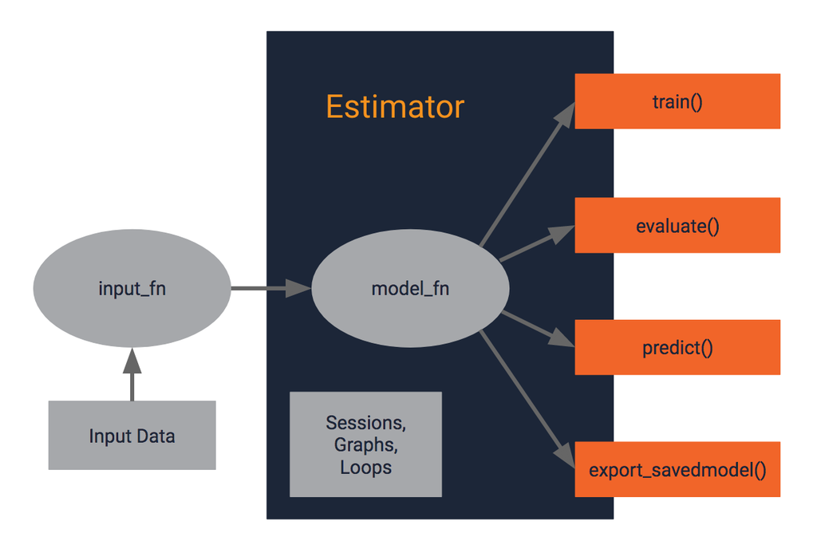

The tfestimators framework makes it easy to construct and build machine learning models via its high-level Estimator API. `Estimator` offers classes you can instantiate to quickly configure common model types such as regressors and classifiers.

But what if none of the predefined model types meets your needs? Perhaps you need more granular control over model configuration, such as the ability to customize the loss function used for optimization, or specify different activation functions for each neural network layer. Or maybe you’re implementing a ranking or recommendation system, and neither a classifier nor a regressor is appropriate for generating predictions. The figure on the right illustrates the basic components of an estimator. Users can implement custom behaviors and or architecture inside the `model_fn` of the estimator.

This tutorial covers how to create your own `Estimator` using the building blocks provided in `tfestimators` package, which will predict the ages of [abalones](https://en.wikipedia.org/wiki/Abalone) based on their physical measurements. You’ll learn how to do the following:

- Instantiate an `Estimator`
- Construct a custom model function
- Configure a neural network using `tf$feature_column` and `tf$layers`
- Choose an appropriate loss function from `tf$losses`
- Define a training op for your model
- Generate and return predictions

The complete code for this tutorial can be found [here](https://github.com/rstudio/tfestimators/blob/main/vignettes/creating_estimators.Rmd).

# An Abalone Age Predictor

It’s possible to estimate the age of an [abalone](https://en.wikipedia.org/wiki/Abalone) (sea snail) by the number of rings on its shell. However, because this task requires cutting, staining, and viewing the shell under a microscope, it’s desirable to find other measurements that can predict age.

The [Abalone Data Set](https://archive.ics.uci.edu/ml/datasets/Abalone) contains the following [feature data](https://archive.ics.uci.edu/ml/machine-learning-databases/abalone/abalone.names) for abalone:

| Feature | Description |
| --- | --- |
| Length | Length of abalone (in longest direction; in mm) |
| Diameter | Diameter of abalone (measurement perpendicular to length; in mm) |
| Height | Height of abalone (with its meat inside shell; in mm) |
| Whole Weight | Weight of entire abalone (in grams) |
| Shucked Weight | Weight of abalone meat only (in grams) |
| Viscera Weight | Gut weight of abalone (in grams), after bleeding |
| Shell Weight | Weight of dried abalone shell (in grams) |

# Setup

This tutorial uses three data sets. [`abalone_train.csv`](http://download.tensorflow.org/data/abalone_train.csv) contains labeled training data comprising 3,320 examples. [`abalone_test.csv`](http://download.tensorflow.org/data/abalone_test.csv) contains labeled test data for 850 examples. [`abalone_predict`](http://download.tensorflow.org/data/abalone_predict.csv) contains 7 examples on which to make predictions.

The following sections walk through writing the `Estimator` code step by step; the [full, final code is available here](https://github.com/tensorflow/tensorflow/blob/r1.3/tensorflow/examples/tutorials/estimators/abalone.py).

# Downloading and Loading Abalone CSV Data

We first write a function that downloads the training, testing, and evaluation data from TensorFlow website if we haven’t downloaded them before.

```r
library(tfestimators)

maybe_download_abalone <- function(train_data_path, test_data_path, predict_data_path, column_names_to_assign) {
  if (!file.exists(train_data_path) || !file.exists(test_data_path) || !file.exists(predict_data_path)) {
    cat("Downloading abalone data ...")
    train_data <- read.csv("http://download.tensorflow.org/data/abalone_train.csv", header = FALSE)
    test_data <- read.csv("http://download.tensorflow.org/data/abalone_test.csv", header = FALSE)
    predict_data <- read.csv("http://download.tensorflow.org/data/abalone_predict.csv", header = FALSE)
    colnames(train_data) <- column_names_to_assign
    colnames(test_data) <- column_names_to_assign
    colnames(predict_data) <- column_names_to_assign
    write.csv(train_data, train_data_path, row.names = FALSE)
    write.csv(test_data, test_data_path, row.names = FALSE)
    write.csv(predict_data, predict_data_path, row.names = FALSE)
  } else {
    train_data <- read.csv(train_data_path, header = TRUE)
    test_data <- read.csv(test_data_path, header = TRUE)
    predict_data <- read.csv(predict_data_path, header = TRUE)
  }
  return(list(train_data = train_data, test_data = test_data, predict_data = predict_data))
}

COLNAMES <- c("length", "diameter", "height", "whole_weight", "shucked_weight", "viscera_weight", "shell_weight", "num_rings")

downloaded_data <- maybe_download_abalone(
  file.path(getwd(), "train_abalone.csv"),
  file.path(getwd(), "test_abalone.csv"),
  file.path(getwd(), "predict_abalone.csv"),
  COLNAMES
)
train_data <- downloaded_data$train_data
test_data <- downloaded_data$test_data
predict_data <- downloaded_data$predict_data
```

Next, we construct the input function as follows:

```r
constructed_input_fn <- function(dataset) {
  input_fn(dataset, features = -num_rings, response = num_rings, num_epochs = NULL)
}
train_input_fn <- constructed_input_fn(train_data)
test_input_fn <- constructed_input_fn(test_data)
predict_input_fn <- constructed_input_fn(predict_data)
```

# Instantiating an Estimator

When defining a model using one of tf.estimator’s provided classes, such as `linear_dnn_combined_classifier`, you supply all the configuration parameters right in the constructor, e.g.:

```r
diameter <- column_numeric("diameter")
height <- column_numeric("height")

model <- dnn_linear_combined_classifier(
  linear_feature_columns = feature_columns(diameter),
  dnn_feature_columns = feature_columns(height),
  dnn_hidden_units = c(100L, 50L)
)
```

You don’t need to write any further code to instruct TensorFlow how to train the model, calculate loss, or return predictions; that logic is already baked into the `linear_dnn_combined_classifier`.

By contrast, when you’re creating your own estimator from scratch, the constructor accepts just two high-level parameters for model configuration, `model_fn` and `params`:

```r
model <- estimator(model_fn, params = model_params)
```

- `model_fn`: A function object that contains all the aforementioned logic to support training, evaluation, and prediction. You are responsible for implementing that functionality. The next section, Constructing the `model_fn` covers creating a model function in detail.
- `params`: An optional dict of hyperparameters (e.g., learning rate, dropout) that will be passed into the `model_fn`.

Note: Just like `tfestimators`’ predefined regressors and classifiers, the `estimator` initializer also accepts the general configuration arguments `model_dir` and `config`.

For the abalone age predictor, the model will accept one hyperparameter: learning rate. Here, `learning_rate` is set to `0.001`, but you can tune this value as needed to achieve the best results during model training.

The following code creates the list `model_params` containing the learning rate and instantiates the `Estimator`:

```r
# Set model params
model_params <- list(learning_rate = 0.001)

# Instantiate Estimator
model <- estimator(model_fn, params = model_params)
```

# Constructing the model_fn

The basic skeleton for an `Estimator` API model function looks like this:

```r
model_fn <- function(features, labels, mode, params, config) {
  # Logic to do the following:
  # 1. Configure the model via TensorFlow operations
  # 2. Define the loss function for training/evaluation
  # 3. Define the training operation/optimizer
  # 4. Generate predictions
  # 5. Return predictions/loss/train_op/eval_metric_ops in estimator_spec object
}
```

The `model_fn` must accept three arguments:

- `features`: A dict containing the features passed to the model via `input_fn`.
- `labels`: A `Tensor` containing the labels passed to the model via `input_fn`. Will be empty for `predict()` calls, as these are the values the model will infer.
- `mode`: One of the following `mode_keys()` string values indicating the context in which the model_fn was invoked:
  - `"train"` The `model_fn` was invoked in training mode, namely via a `train()` call.
  - `"eval"`. The `model_fn` was invoked in evaluation mode, namely via an `evaluate()` call.
  - `"infer"`. The `model_fn` was invoked in predict mode, namely via a `predict()` call.

`model_fn` may also accept a `params` argument containing a dict of hyperparameters used for training (as shown in the skeleton above) and a `config` that represents the configurations used in a model, including GPU percentage, cluster information, etc.

The body of the function performs the following tasks (described in detail in the sections that follow):

- Configuring the model—here, for the abalone predictor, this will be a neural network.
- Defining the loss function used to calculate how closely the model’s predictions match the target values.
- Defining the training operation that specifies the `optimizer` algorithm to minimize the loss values calculated by the loss function.

The `model_fn` must return an `estimator_spec` object, which contains the following values:

- `mode` (required). The mode in which the model was run. Typically, you will return the `mode` argument of the `model_fn` here.
- `predictions` (required in `infer` mode). A dict that maps key names of your choice to `Tensor`s containing the predictions from the model, e.g.:

```r
predictions <- list(results = tensor_of_predictions)
```

In `infer` mode, the dict that you return in `estimator_spec` will then be returned by `predict()`, so you can construct it in the format in which you’d like to consume it.

- `loss` (required in `eval` and `train` modes). A `Tensor` containing a scalar loss value: the output of the model’s loss function (discussed in more depth later in Defining loss for the model) calculated over all the input examples. This is used in `train` mode for error handling and logging, and is automatically included as a metric in `eval` mode.
- `train_op` (required only in `train` mode). An Op that runs one step of training.
- `eval_metric_ops` (optional). A dict of name/value pairs specifying the metrics that will be calculated when the model runs in `eval` mode. The name is a label of your choice for the metric, and the value is the result of your metric calculation. The `tf$metrics` module provides predefined functions for a variety of common metrics. The following `eval_metric_ops` contains an `"accuracy"` metric calculated using `tf$metrics$accuracy`:

```r
eval_metric_ops <- list(accuracy = tf$metrics$accuracy(labels, predictions))
```

If you do not specify `eval_metric_ops`, only `loss` will be calculated during evaluation.

## Configuring a neural network with feature_column and layers

Constructing a [neural network](https://en.wikipedia.org/wiki/Artificial_neural_network) entails creating and connecting the input layer, the hidden layers, and the output layer.

The input layer is a series of nodes (one for each feature in the model) that will accept the feature data that is passed to the `model_fn` in the `features` argument. If `features` contains an n-dimensional `Tensor` with all your feature data, then it can serve as the input layer. If `features` contains a dict of feature columns passed to the model via an input function, you can convert it to an input-layer `Tensor` with the `input_layer` function:

```r
input_layer <- input_layer(
    features = features, feature_columns = c(age, height, weight))
```

As shown above, `input_layer()` takes two required arguments:

- `features`. A mapping from string keys to the `Tensors` containing the corresponding feature data. This is exactly what is passed to the `model_fn` in the `features` argument.
- `feature_columns`. A list of all the `FeatureColumns` in the model — `age`, `height`, and `weight` in the above example.

The input layer of the neural network then must be connected to one or more hidden layers via an [activation function](https://en.wikipedia.org/wiki/Activation_function) that performs a nonlinear transformation on the data from the previous layer. The last hidden layer is then connected to the output layer, the final layer in the model. `tf$layers` provides the `tf$layers$dense` function for constructing fully connected layers. The activation is controlled by the `activation` argument. Some options to pass to the `activation` argument are:

- `tf$nn$relu`. The following code creates a layer of `units` nodes fully connected to the previous layer `input_layer` with a ReLU activation function:

```r
hidden_layer <- tf$layers$dense(inputs = input_layer, units = 10L, activation = tf$nn$relu)
```

```r
second_hidden_layer <- tf$layers$dense(
inputs = hidden_layer, units = 20L, activation = tf$nn$relu)
```

- `NULL`. The following code creates a layer of `units` nodes fully connected to the previous layer `second_hidden_layer` with *no* activation function, just a linear transformation:

```r
output_layer <- tf$layers$dense(inputs = second_hidden_layer,
units = 3L, activation = NULL)
```

Other activation functions are possible, e.g.:

```r
output_layer <- tf$layers$dense(inputs = second_hidden_layer,
units = 10L, activation_fn = tf$sigmoid)
```

The above code creates the neural network layer `output_layer`, which is fully connected to `second_hidden_layer` with a sigmoid activation function `tf$sigmoid`.

The network contains two hidden layers, each with 10 nodes and a ReLU activation function. The output layer contains no activation function, and is `tf$reshape` to a one-dimensional tensor to capture the model’s predictions, which are stored in `predictions_dict`.

## Defining loss for the model

The `estimator_spec` returned by the `model_fn` must contain `loss`: a `Tensor` representing the loss value, which quantifies how well the model’s predictions reflect the label values during training and evaluation runs. The `tf$losses` module provides convenience functions for calculating loss using a variety of metrics, including:

- `absolute_difference(labels, predictions)`. Calculates loss using the absolute-difference formula (also known as L<sub>1</sub> loss).
- `log_loss(labels, predictions)`. Calculates loss using the [logistic loss forumula](https://en.wikipedia.org/wiki/Loss_functions_for_classification#Logistic_loss) (typically used in logistic regression).
- `mean_squared_error(labels, predictions)`. Calculates loss using the [mean squared error](https://en.wikipedia.org/wiki/Mean_squared_error) (MSE; also known as L<sub>2</sub> loss).

The following example adds a definition for `loss` to the abalone `model_fn` using `mean_squared_error()`:

```r
loss <- tf$losses$mean_squared_error(labels, predictions)
```

Supplementary metrics for evaluation can be added to an `eval_metric_ops` dict. The following code defines an `rmse` metric, which calculates the root mean squared error for the model predictions. Note that the `labels` tensor is cast to a `float64` type to match the data type of the `predictions` tensor, which will contain real values:

```r
eval_metric_ops <- list(rmse = tf$metrics$root_mean_squared_error(
tf$cast(labels, tf$float64), predictions
))
```

## Defining the training op for the model

The training op defines the optimization algorithm TensorFlow will use when fitting the model to the training data. Typically when training, the goal is to minimize loss. A simple way to create the training op is to instantiate a `tf$train$Optimizer` subclass and call the `minimize` method.

The following code defines a training op for the abalone `model_fn` using the loss value calculated in Defining Loss for the Model, the learning rate passed to the function in `params`, and the gradient descent optimizer. For `global_step`, the convenience function `tf$train$get_global_step` takes care of generating an integer variable:

```r
optimizer <- tf$train$GradientDescentOptimizer(learning_rate = params$learning_rate)
train_op <- optimizer$minimize(loss = loss, global_step = tf$train$get_global_step())
```

## The complete abalone model_fn

Here’s the final, complete `model_fn` for the abalone age predictor. The following code configures the neural network; defines loss and the training op; and returns a `estimator_spec` object containing `mode`, `predictions_dict`, `loss`, and `train_op`:

```r
model_fn <- function(features, labels, mode, params, config) {
  # Connect the first hidden layer to input layer
  first_hidden_layer <- tf$layers$dense(features, 10L, activation = tf$nn$relu)

  # Connect the second hidden layer to first hidden layer with relu
  second_hidden_layer <- tf$layers$dense(first_hidden_layer, 10L, activation = tf$nn$relu)

  # Connect the output layer to second hidden layer (no activation fn)
  output_layer <- tf$layers$dense(second_hidden_layer, 1L)

  # Reshape output layer to 1-dim Tensor to return predictions
  predictions <- tf$reshape(output_layer, list(-1L))
  predictions_list <- list(ages = predictions)

  # Calculate loss using mean squared error
  loss <- tf$losses$mean_squared_error(labels, predictions)

  eval_metric_ops <- list(rmse = tf$metrics$root_mean_squared_error(
    tf$cast(labels, tf$float64), predictions
  ))

  optimizer <- tf$train$GradientDescentOptimizer(learning_rate = params$learning_rate)
  train_op <- optimizer$minimize(loss = loss, global_step = tf$train$get_global_step())

  return(estimator_spec(
    mode = mode,
    predictions = predictions_list,
    loss = loss,
    train_op = train_op,
    eval_metric_ops = eval_metric_ops
  ))
}

model_params <- list(learning_rate = 0.001)
model <- estimator(model_fn, params = model_params)
```

# Running the Abalone Model

You’ve instantiated an `Estimator` for the abalone predictor and defined its behavior in `model_fn`; all that’s left to do is train, evaluate, and make predictions.

The following code fits the neural network to the training data and evaluates the model performance based on the `eval_metric_ops` that we have defined:

```r
train(model, input_fn = train_input_fn, steps = 2)

evaluate(model, input_fn = test_input_fn, steps = 2)
```